# **News Classification Based on Headline**

#### Aim of the Project:

News information was not easily and quickly available until the beginning of last decade. But now news is easily accessible via content providers such as online news services.A huge amount of information exists in form of text in various diverse areas whose analysis can be beneficial in several areas. Classification is quite a challenging field in text mining as it requires prepossessing steps to convert unstructured data to structured information. With the increase in the number of news it has got difficult for users to access news of his interest which makes it a necessity to categories news so that it could be easily accessed. Categorization refers to grouping that allows easier navigation among articles. Internet news needs to be divided into categories. This will help users to access the news of their interest in real-time without wasting any time.

The project makes uses of few machine learing algorithms to classify the news into different category.The datset is collected from some online source and in saved in person system.Data may be in available in any format i.e. it may in .pdf, .doc, or in .html format.In this project the data is available in .csv format.

#### Models implemented:

- Multinomial Naive Bayes
- SGD Classifier
- MLP Classifier

#### *Importing the library*

```python
import pandas as pd
from sklearn.preprocessing import LabelEncoder

from sklearn.feature_extraction.text import TfidfVectorizer
from sklearn.model_selection import train_test_split

from sklearn.naive_bayes import MultinomialNB
from sklearn.linear_model import SGDClassifier
from sklearn.neural_network import MLPClassifier

import seaborn as sns
import matplotlib.pyplot as plt

from sklearn.metrics import accuracy_score,classification_report,confusion_matrix
```

```python
#Filter the unwanted warning
import warnings
warnings.simplefilter("ignore")
```

#### *Reading the Dataset*

```python
df = pd.read_csv("news_title.csv",)
```

```python
#Printing first five column of Sataset
df.head()
```

|  | Unnamed: 0 | index | authors | category | date | headline | link | short_description |
| --- | --- | --- | --- | --- | --- | --- | --- | --- |
| 0 | 1 | 4297 | Andy McDonald | ENTERTAINMENT | 2018-03-08 | Comedy Sketch Gives A Look At The First Russia... | https://www.huffingtonpost.com/entry/comedy-sk... | "The truth can be very dangerous." |
| 1 | 5 | 27360 | Jennifer Rand, ContributorLawyer, political ac... | POLITICS | 2017-05-06 | What Should Really Bother You About The Rockvi... | https://www.huffingtonpost.com/entry/what-shou... | The sexual assault charges have just been drop... |
| 2 | 7 | 11026 | James Zogby, ContributorPresident, Arab Americ... | POLITICS | 2017-11-25 | Palestinians: Victims Of An Unjust US Law | https://www.huffingtonpost.com/entry/palestini... | The law in question punishes the victim while ... |
| 3 | 9 | 3607 | Lee Moran | POLITICS | 2018-03-21 | Tweeters School 'Amazingly Dumb' Donald Trump ... | https://www.huffingtonpost.com/entry/donald-tr... | "The Special Council is a unit of the Space Fo... |
| 4 | 22 | 81320 | NaN | POLITICS | 2015-09-01 | Missouri Executes Man For Raping, Killing Girl... | https://www.huffingtonpost.com/entry/missouri-... | Nunley would be the sixth death row inmate to ... |

##### The features in this data set are described as below:

- Index : Serial Number
- Author : Author of News Article
- Category : Category of the News Article
- Date : Date of Posted News
- Headline : Headline of News
- Link : Online Link for Article

##### Categories of News

- Political News
- Entertainment
- Style And Beauty
- Food And Drink
- Business

```python
df["category"].value_counts()
```

```
POLITICS          32739
ENTERTAINMENT     16058
STYLE & BEAUTY     9649
FOOD & DRINK       6226
BUSINESS           5937
Name: category, dtype: int64
```

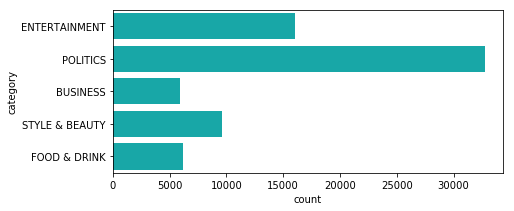

```python
#Plotting histogram to see count of each category
f, ax = plt.subplots(figsize=(7, 3))
sns.countplot(y="category", data=df, color="c");
```

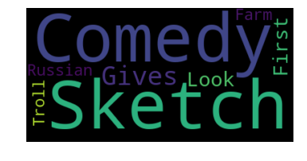

```python
# importing all necessery modules
from wordcloud import WordCloud, STOPWORDS

# Start with one headline:
text = df.headline[0]

# Create and generate a word cloud image:
wordcloud = WordCloud().generate(text)

# Display the generated image:
plt.imshow(wordcloud, interpolation='bilinear')
plt.axis("off")
plt.show()
```

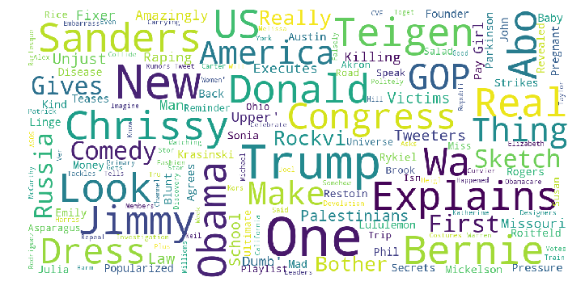

```python
#importing the module
from wordcloud import WordCloud, STOPWORDS

#stopwords or unnecessary words
stopwords = set(STOPWORDS)

def show_wordcloud(data, title = None):
    wordcloud = WordCloud(
        background_color='white',
        stopwords=stopwords,
        max_words=200,
        max_font_size=40,
        scale=3,
        random_state=1 # chosen at random by flipping a coin; it was heads
    ).generate(str(data))

    fig = plt.figure(1, figsize=(12, 12))
    plt.axis('off')
    if title:
        fig.suptitle(title, fontsize=20)
        fig.subplots_adjust(top=2.3)

    plt.imshow(wordcloud)
    plt.show()

#function call
show_wordcloud(df['headline'])
```

```python
#Printing all the possible category of news
labels = list(set(df["category"]))
print('possible categories',labels)
```

```
possible categories ['POLITICS', 'FOOD & DRINK', 'STYLE & BEAUTY', 'BUSINESS', 'ENTERTAINMENT']
```

We are only working with the two variables i.e headline and category so we will try now to create new dataframe which consist only headline and category.

```python
#Creating new DataFrame
headline=df["headline"]
cate=df["category"]
df_new=pd.DataFrame(headline,columns=["headline"])
df_new=df_new.join(cate)
df_new.head()
```

|  | headline | category |
| --- | --- | --- |
| 0 | Comedy Sketch Gives A Look At The First Russia... | ENTERTAINMENT |
| 1 | What Should Really Bother You About The Rockvi... | POLITICS |
| 2 | Palestinians: Victims Of An Unjust US Law | POLITICS |
| 3 | Tweeters School 'Amazingly Dumb' Donald Trump ... | POLITICS |
| 4 | Missouri Executes Man For Raping, Killing Girl... | POLITICS |

Now we will try to drop all the row which have null values.

```python
df_new.dropna(inplace=True)
```

```python
#Checking the number of column with null values
df_new.isnull().sum()
```

```
headline    0
category    0
dtype: int64
```

We have deleted all the rows will null valuenow we can start engineering and training our model.

```python
X=df["headline"]
Y=df["category"]
```

Each vector can be considered a *bag of words*. By itself these may not be helpful until we consider *term frequencies*, or how often individual words appear in documents. A simple way to calculate term frequencies is to divide the number of occurrences of a word by the total number of words in the document. In this way, the number of times a word appears in large documents can be compared to that of smaller documents.

However, it may be hard to differentiate documents based on term frequency if a word shows up in a majority of documents. To handle this we also consider *inverse document frequency*, which is the total number of documents divided by the number of documents that contain the word.

As tf–idf is very often used for text features, there is also another class called TfidfVectorizer that combines all the options of CountVectorizer and TfidfTransformer in a single model.

```python
vectorizer=TfidfVectorizer()
x = vectorizer.fit_transform(df['headline'].values.astype('U'))
x.shape
```

```
(70609, 33119)
```

```python
x
```

```
<70609x33119 sparse matrix of type '<class 'numpy.float64'>'
	with 686451 stored elements in Compressed Sparse Row format>
```

### Splitting the data into train and test

Split arrays or matrices into random train and test subsets

```python
X_train,X_test,y_train,y_test=train_test_split(x,Y,test_size=0.2,random_state=0)
```

```python
#Printing the shape and size of the train and testv
print('X_train.shape',X_train.shape)
print('y_train.shape',y_train.shape)
print('X_test.shape',X_test.shape)
print('y_test.shape',y_test.shape)
```

```
X_train.shape (56487, 33119)
y_train.shape (56487,)
X_test.shape (14122, 33119)
y_test.shape (14122,)
```

### Model Building

##### Multinomial NaiveBayes

It estimates the conditional probability of a particular word given a class as the relative frequency of term t in documents belonging to class(c). The variation takes into account the number of occurrences of term t in training documents from class (c),including multiple occurrences.

```python
#Building the Model
model=MultinomialNB()
text_clf = model.fit(X_train, y_train)
```

```python
#Predicting from the fitted model on train data
print('Predicting...\nIn Training Data')
predicted = text_clf.predict(X_train)
```

```
Predicting...
In Training Data
```

```python
#Predicting from the fitted model on test data
pred1=text_clf.predict(X_test)
```

```python
#Printing the accuracy of the model
acc1=accuracy_score(pred1,y_test)
print("Accuracy for Training Data : ",accuracy_score(predicted,y_train))
print("Accuracy for Testing Data : ",accuracy_score(pred1,y_test))
```

```
Accuracy for Training Data :  0.8466903889390479
Accuracy for Testing Data :  0.8136949440589152
```

```python
print(confusion_matrix(pred1,y_test))
```

```
[[ 137    1    1    4    3]
 [  56 2608   98   86  201]
 [   7    0  823    2   10]
 [ 944  623  262 6445  239]
 [  10   49   34    1 1478]]
```

#### SGD Classifier

Stochastic Gradient Descent (SGD) is a simple yet very efficient approach to discriminative learning of linear classifiers under convex loss functions such as (linear) Support Vector Machines and Logistic Regression. Even though SGD has been around in the machine learning community for a long time, it has received a considerable amount of attention just recently in the context of large-scale learning.

SGD has been successfully applied to large-scale and sparse machine learning problems often encountered in text classification and natural language processing. Given that the data is sparse, the classifiers in this module easily scale to problems with more than 10^5 training examples and more than 10^5 features.

The class SGDClassifier implements a plain stochastic gradient descent learning routine which supports different loss functions and penalties for classification.

[figure not shown]

```python
#Building the Model
sgd = SGDClassifier(n_jobs=-1, n_iter=10, random_state=1234)
sgd.fit(X_train,y_train)
```

```
SGDClassifier(alpha=0.0001, average=False, class_weight=None,
       early_stopping=False, epsilon=0.1, eta0=0.0, fit_intercept=True,
       l1_ratio=0.15, learning_rate='optimal', loss='hinge', max_iter=None,
       n_iter=10, n_iter_no_change=5, n_jobs=-1, penalty='l2', power_t=0.5,
       random_state=1234, shuffle=True, tol=None, validation_fraction=0.1,
       verbose=0, warm_start=False)
```

```python
#Predicting from the fitted model on train data
print('Predicting...\nIn Training Data')
predicted = sgd.predict(X_train)
```

```
Predicting...
In Training Data
```

```python
#Predicting from the fitted model on test data
pred2=sgd.predict(X_test)
```

```python
#Printing the accuracy of the model
acc2=accuracy_score(pred2,y_test)
print("Accuracy for Training Data : ",accuracy_score(predicted,y_train))
print("Accuracy for Testing Data : ",accuracy_score(pred2,y_test))
```

```
Accuracy for Training Data :  0.8999415794784641
Accuracy for Testing Data :  0.8693527828919416
```

```python
print(confusion_matrix(pred2,y_test))
```

```
[[ 533   20   11   52   17]
 [  91 2796   60  129  164]
 [  42   17  992   10   20]
 [ 468  381   83 6331  105]
 [  20   67   72   16 1625]]
```

#### MLP Classifier

MLPClassifier stands for Multi-layer Perceptron classifier which in the name itself connects to a Neural Network. Unlike other classification algorithms such as Support Vectors or Naive Bayes Classifier, MLPClassifier relies on an underlying Neural Network to perform the task of classification.

An MLP consists of at least three layers of nodes: an input layer, a hidden layer and an output layer. Except for the input nodes, each node is a neuron that uses a nonlinear activation function. MLP utilizes a supervised learning technique called backpropagation for training. Its multiple layers and non-linear activation distinguish MLP from a linear perceptron. It can distinguish data that is not linearly separable.

```python
#Building the Model
clf_neural = MLPClassifier(solver='lbfgs', alpha=1e-5, hidden_layer_sizes=(25,),random_state=1)
clf_neural.fit(X_train, y_train)
```

```
MLPClassifier(activation='relu', alpha=1e-05, batch_size='auto', beta_1=0.9,
       beta_2=0.999, early_stopping=False, epsilon=1e-08,
       hidden_layer_sizes=(25,), learning_rate='constant',
       learning_rate_init=0.001, max_iter=200, momentum=0.9,
       n_iter_no_change=10, nesterovs_momentum=True, power_t=0.5,
       random_state=1, shuffle=True, solver='lbfgs', tol=0.0001,
       validation_fraction=0.1, verbose=False, warm_start=False)
```

```python
#Predicting from the fitted model on train data
print('Predicting...\nIn Training Data')
predicted = clf_neural.predict(X_train)
```

```
Predicting...
In Training Data
```

```python
print('Predicting...\nIn Testing Data')
pred3=clf_neural.predict(X_test)
```

```
Predicting...
In Testing Data
```

```python
#Printing the accuracy of the model
acc3=accuracy_score(pred3,y_test)
print("Accuracy for Training Data : ",accuracy_score(predicted,y_train))
print("Accuracy for Testing Data : ",accuracy_score(pred3,y_test))
```

```
Accuracy for Training Data :  0.9802078354311612
Accuracy for Testing Data :  0.8764339328706982
```

```python
print(confusion_matrix(pred3,y_test))
```

```
[[ 778   72   54  212   38]
 [  54 2828   42  208  136]
 [  39   22 1024   20   21]
 [ 252  264   48 6068   57]
 [  31   95   50   30 1679]]
```

## Summary

Applying MLP classifier gave us the maximum accuracy of 87%. Thus this model can be used to determine the category of news from the set news.The model can be more improved by using more complex neural network.